# UFC Predictions

2026-11-20

# 1. Business Question

**Can we predict which fighter will win their next UFC fight using only information known before the fight starts?**

Who benefits: matchmakers, sportsbooks and bettors, fighter representation (contract leverage, opponent selection), and media. Success metric: out-of-sample accuracy and AUC compared with two baselines: (1) always predict the majority corner, and (2) always pick the betting favorite.

# 2. Data Loading and Cleaning

```r
ufc <- read.csv("ufc-master.csv")
dim(ufc)
```

```
## [1] 7177  118
```

```r
# ---- Deleting columns ----
# NOTE: "date" is no longer dropped here. We need it to split 2025 (train) from 2026 (predict).
drop_cols <- c("location", "country", "lose_streak_dif", "win_streak_dif",
               "longest_win_streak_dif", "win_dif", "loss_dif", "total_round_dif",
               "total_title_bout_dif", "ko_dif", "sub_dif", "height_dif", "reach_dif",
               "age_dif", "sig_str_dif", "avg_sub_att_dif", "avg_td_dif", "empty_arena",
               "R_Women.s.Featherweight_rank", "B_Women.s.Featherweight_rank",
               "finish_details", "finish_round_time", "total_fight_time_secs")
ufc[intersect(drop_cols, names(ufc))] <- NULL

# ---- Parse the fight date (handles both "2025-03-15" and "3/15/2025") ----
parse_fight_date <- function(x) {
  x <- as.character(x)
  d <- as.Date(x, format = "%Y-%m-%d")
  d[is.na(d)] <- as.Date(x[is.na(d)], format = "%m/%d/%Y")
  d
}
ufc$date <- parse_fight_date(ufc$date)
ufc$year <- as.integer(format(ufc$date, "%Y"))

# ---- Factorizing columns ----
factor_cols <- c("R_fighter", "B_fighter", "Winner", "title_bout", "weight_class",
                 "gender", "no_of_rounds", "B_Stance", "R_Stance", "better_rank", "finish")
ufc[factor_cols] <- lapply(ufc[factor_cols], as.factor)

# ---- Reconfiguring ranked columns: NA = unranked (0), otherwise ranked (1) ----
rank_cols <- grep("_rank$", names(ufc), value = TRUE)
for (col in rank_cols) {
  ufc[[paste0(col, "2")]] <- ifelse(is.na(ufc[[col]]), 0, 1)
  ufc[[col]] <- NULL
}

str(ufc)
```

```
## 'data.frame':    7177 obs. of  96 variables:
##  $ R_fighter                   : Factor w/ 1771 levels " Jun Yong Park",..: 683 62 1175 896 1086 1604 662 292 1099 270 ...
##  $ B_fighter                   : Factor w/ 2054 levels "Aalon Cruz","Aaron Phillips",..: 940 1353 1495 1180 2027 1150 1897 1159 1932 681 ...
##  $ R_odds                      : num  -130 124 -901 235 -158 -150 -295 -280 -104 -113 ...
##  $ B_odds                      : num  102 -158 550 -320 124 118 220 210 -122 -113 ...
##  $ R_ev                        : num  76.9 124 11.1 235 63.3 ...
##  $ B_ev                        : num  102 63.3 550 31.2 124 ...
##  $ date                        : Date, format: "2026-03-28" "2026-03-28" ...
##  $ Winner                      : Factor w/ 4 levels "Blue","Draw",..: 1 4 4 1 1 4 1 1 1 4 ...
##  $ title_bout                  : Factor w/ 2 levels "False","True": 1 1 1 1 1 1 1 1 1 1 ...
##  $ weight_class                : Factor w/ 13 levels "Bantamweight",..: 8 12 9 3 8 7 7 7 5 12 ...
##  $ gender                      : Factor w/ 2 levels "FEMALE","MALE": 2 1 2 2 2 2 2 2 2 1 ...
##  $ no_of_rounds                : Factor w/ 3 levels "3","4","5": 3 1 1 1 1 1 1 1 1 1 ...
##  $ B_current_lose_streak       : int  0 0 3 0 0 0 1 1 0 0 ...
##  $ B_current_win_streak        : int  3 7 0 1 2 1 0 0 0 3 ...
```

[output cut: 82 more lines]

```r
# Keep a copy of EVERY fight before filtering. 2026 fights that haven't
# happened yet have no Winner, and we still want to predict them in Section 6.
ufc_all <- ufc

# Keep only fights with a clean Red/Blue target
table(ufc$Winner)
```

```
##
##       Blue       Draw No Contest        Red
##       3024          5          3       4145
```

```r
ufc <- ufc[ufc$Winner %in% c("Red", "Blue"), ]
ufc$Winner <- droplevels(ufc$Winner)

# Missing values summary
na_counts <- colSums(is.na(ufc))
na_counts[na_counts > 0]
```

```
##               R_odds               B_odds                 R_ev
##                  240                  239                  240
##                 B_ev B_avg_SIG_STR_landed    B_avg_SIG_STR_pct
##                  239                  930                  765
##        B_avg_SUB_ATT      B_avg_TD_landed         B_avg_TD_pct
##                  832                  833                  842
## R_avg_SIG_STR_landed    R_avg_SIG_STR_pct        R_avg_SUB_ATT
##                  455                  357                  357
##      R_avg_TD_landed         R_avg_TD_pct         finish_round
##                  357                  367                  622
##           r_dec_odds           b_dec_odds           r_sub_odds
##                 1115                 1145                 1364
##           b_sub_odds            r_ko_odds            b_ko_odds
##                 1388                 1362                 1389
```

```r
# Stance: treat blank/NA as its own category
for (s in c("B_Stance", "R_Stance")) {
  ufc[[s]] <- as.character(ufc[[s]])
  ufc[[s]][is.na(ufc[[s]]) | ufc[[s]] == ""] <- "Unknown"
  ufc[[s]] <- as.factor(ufc[[s]])
}

# Numeric columns: median imputation
num_cols <- names(ufc)[sapply(ufc, is.numeric)]
for (col in num_cols) {
  ufc[[col]][is.na(ufc[[col]])] <- median(ufc[[col]], na.rm = TRUE)
}
sum(is.na(ufc))
```

```
## [1] 0
```

# 3. Exploration

```r
# Target balance
prop.table(table(ufc$Winner))
```

```
##
##      Blue       Red
## 0.4218162 0.5781838
```

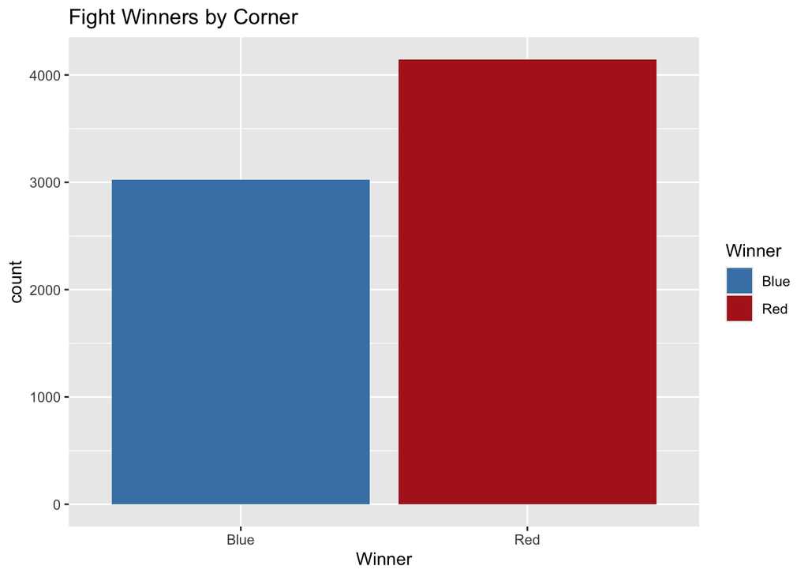

```r
ggplot(ufc, aes(Winner, fill = Winner)) +
  geom_bar() +
  scale_fill_manual(values = c(Blue = "steelblue", Red = "firebrick")) +
  labs(title = "Fight Winners by Corner")
```

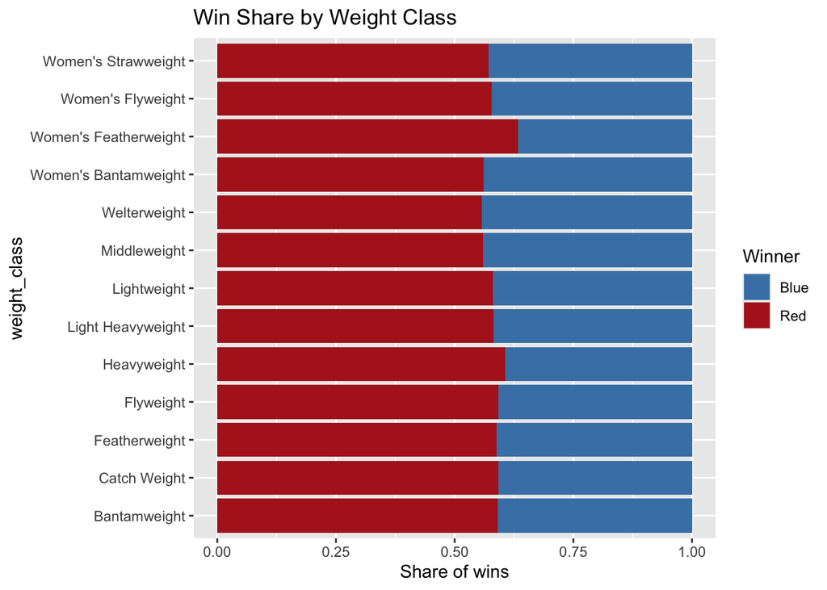

```r
# Win share by weight class
ggplot(ufc, aes(weight_class, fill = Winner)) +
  geom_bar(position = "fill") + coord_flip() +
  scale_fill_manual(values = c(Blue = "steelblue", Red = "firebrick")) +
  labs(y = "Share of wins", title = "Win Share by Weight Class")
```

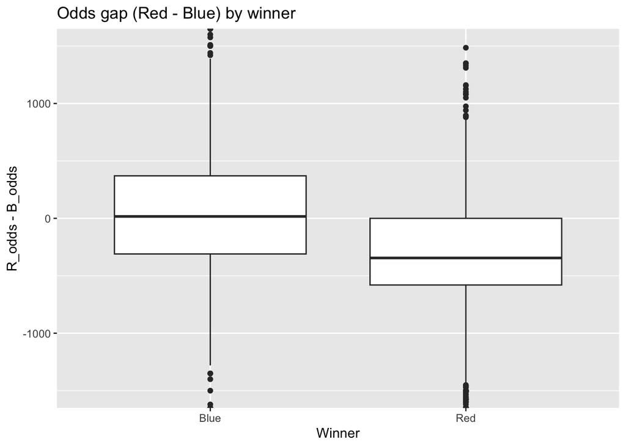

```r
# Betting odds gap vs outcome (odds are known before the fight)
ggplot(ufc, aes(Winner, R_odds - B_odds)) + geom_boxplot() +
  coord_cartesian(ylim = c(-1500, 1500)) + labs(title = "Odds gap (Red - Blue) by winner")
```

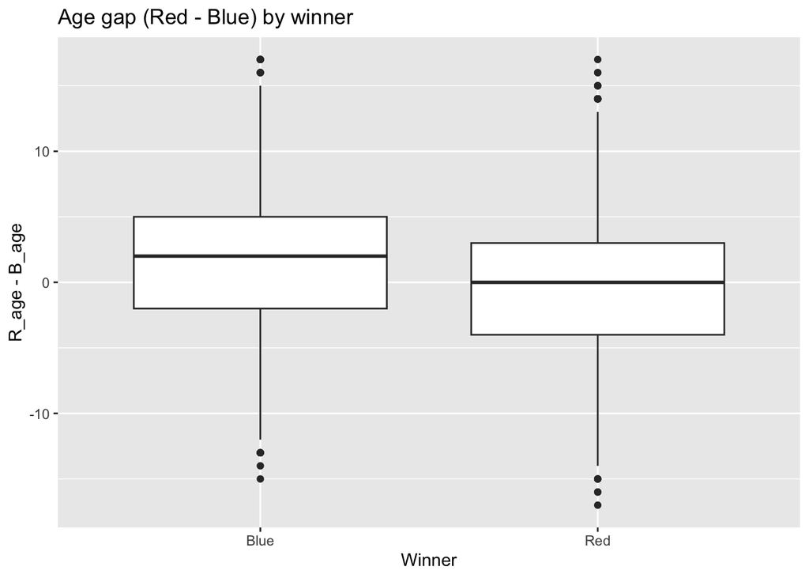

```r
# Age gap by winner
ggplot(ufc, aes(Winner, R_age - B_age)) + geom_boxplot() +
  labs(title = "Age gap (Red - Blue) by winner")
```

# 4. Preparing the Modeling Data

Columns describing what happened during or after the fight (`finish`, `finish_round`) can’t be used to predict it, so they are removed. Fighter names are also dropped, and so are `date` and `year` (they are only used to split the data, not as predictors).

```r
leak_cols <- c("finish", "finish_round", "R_fighter", "B_fighter", "date", "year")
ufc_model <- ufc[, !(names(ufc) %in% leak_cols)]

# Drop near-zero-variance columns
nzv <- nearZeroVar(ufc_model, names = TRUE)
nzv
```

```
##  [1] "title_bout"                   "B_draw"
##  [3] "B_win_by_Decision_Majority"   "B_win_by_TKO_Doctor_Stoppage"
##  [5] "R_draw"                       "R_win_by_Decision_Majority"
##  [7] "R_win_by_TKO_Doctor_Stoppage" "R_Women.s.Flyweight_rank2"
##  [9] "R_Women.s.Strawweight_rank2"  "R_Women.s.Bantamweight_rank2"
## [11] "R_Heavyweight_rank2"          "R_Light.Heavyweight_rank2"
## [13] "R_Middleweight_rank2"         "R_Welterweight_rank2"
## [15] "R_Lightweight_rank2"          "R_Featherweight_rank2"
## [17] "R_Bantamweight_rank2"         "R_Flyweight_rank2"
## [19] "R_Pound.for.Pound_rank2"      "B_Women.s.Flyweight_rank2"
## [21] "B_Women.s.Strawweight_rank2"  "B_Women.s.Bantamweight_rank2"
## [23] "B_Heavyweight_rank2"          "B_Light.Heavyweight_rank2"
## [25] "B_Middleweight_rank2"         "B_Welterweight_rank2"
## [27] "B_Lightweight_rank2"          "B_Featherweight_rank2"
## [29] "B_Bantamweight_rank2"         "B_Flyweight_rank2"
## [31] "B_Pound.for.Pound_rank2"      "better_rank2"
```

```r
ufc_model <- ufc_model[, !(names(ufc_model) %in% nzv)]
dim(ufc_model)
```

```
## [1] 7169   58
```

```r
# Stratified 70/30 train/test split
idx   <- createDataPartition(ufc_model$Winner, p = 0.7, list = FALSE)
train <- ufc_model[idx, ]
test  <- ufc_model[-idx, ]

# Baselines
majority      <- names(which.max(table(train$Winner)))
base_majority <- mean(test$Winner == majority)
fav           <- ifelse(test$R_odds < test$B_odds, "Red", "Blue")  # lower odds = favorite
base_favorite <- mean(fav == test$Winner)
c(majority = base_majority, favorite = base_favorite)
```

```
##  majority  favorite
## 0.5781395 0.6609302
```

# 5. One Quick Regression Model

A simple logistic regression to show the dataset has predictive signal.

```r
quick <- glm(Winner ~ R_odds + B_odds + R_age + B_age + R_Height_cms + B_Height_cms +
               R_Reach_cms + B_Reach_cms + R_wins + B_wins + R_losses + B_losses,
             data = train, family = binomial)
summary(quick)
```

```
##
## Call:
## glm(formula = Winner ~ R_odds + B_odds + R_age + B_age + R_Height_cms +
##     B_Height_cms + R_Reach_cms + B_Reach_cms + R_wins + B_wins +
##     R_losses + B_losses, family = binomial, data = train)
##
## Coefficients:
##                Estimate Std. Error z value Pr(>|z|)
## (Intercept)   0.0682709  0.6977367   0.098 0.922054
## R_odds       -0.0017524  0.0004851  -3.612 0.000303 ***
## B_odds        0.0012670  0.0005008   2.530 0.011411 *
## R_age        -0.0164921  0.0092067  -1.791 0.073242 .
## B_age         0.0182348  0.0091798   1.986 0.046988 *
## R_Height_cms -0.0034702  0.0081846  -0.424 0.671568
## B_Height_cms -0.0078777  0.0077213  -1.020 0.307609
## R_Reach_cms   0.0100678  0.0065593   1.535 0.124814
## B_Reach_cms   0.0009713  0.0058416   0.166 0.867945
## R_wins       -0.0084085  0.0125238  -0.671 0.501965
## B_wins       -0.0088448  0.0141752  -0.624 0.532652
## R_losses      0.0087579  0.0191652   0.457 0.647692
## B_losses      0.0199916  0.0223917   0.893 0.371959
## ---
## Signif. codes:  0 '***' 0.001 '**' 0.01 '*' 0.05 '.' 0.1 ' ' 1
##
## (Dispersion parameter for binomial family taken to be 1)
##
##     Null deviance: 6834.5  on 5018  degrees of freedom
## Residual deviance: 6147.7  on 5006  degrees of freedom
## AIC: 6173.7
##
## Number of Fisher Scoring iterations: 4
```

```r
# glm models P(second factor level) = P(Red), since levels are Blue, Red
p_quick   <- predict(quick, test, type = "response")
cls_quick <- factor(ifelse(p_quick > 0.5, "Red", "Blue"), levels = levels(test$Winner))

confusionMatrix(cls_quick, test$Winner, positive = "Red")
```

```
## Confusion Matrix and Statistics
##
##           Reference
## Prediction Blue Red
##       Blue  453 258
##       Red   454 985
##
##                Accuracy : 0.6688
##                  95% CI : (0.6485, 0.6887)
##     No Information Rate : 0.5781
##     P-Value [Acc > NIR] : < 2.2e-16
##
##                   Kappa : 0.3007
##
##  Mcnemar's Test P-Value : 2.713e-13
##
##             Sensitivity : 0.7924
##             Specificity : 0.4994
##          Pos Pred Value : 0.6845
##          Neg Pred Value : 0.6371
##              Prevalence : 0.5781
##          Detection Rate : 0.4581
##    Detection Prevalence : 0.6693
##       Balanced Accuracy : 0.6459
##
##        'Positive' Class : Red
##
```

```r
auc(roc(test$Winner, p_quick, levels = c("Blue", "Red")))
```

```
## Area under the curve: 0.7203
```

# 6. Two-Level Decision Tree: Train on 2025, Predict 2026

The tree is trained only on 2025 fights and then applied to 2026 fights. This is a true “past predicts future” test: the model never sees any 2026 data. `maxdepth = 2` limits the tree to two levels of splits (at most four end leaves), so every rule it learns is easy to read and explain.

To avoid leaking information from the future, missing values in both years are filled with **2025 medians only**. The predictors are the same columns used in Section 4 (`ufc_model`).

```r
table(ufc_all$year, useNA = "ifany")   # how many fights per year are in the file
```

```
##
## 2010 2011 2012 2013 2014 2015 2016 2017 2018 2019 2020 2021 2022 2023 2024 2025
##  210  295  333  376  494  464  483  440  471  507  451  494  506  504  513  520
## 2026
##  116
```

```r
predictors <- setdiff(names(ufc_model), "Winner")
id_cols    <- c("date", "R_fighter", "B_fighter")

# ---- 2025: training set (completed fights only) ----
train25 <- ufc_all[ufc_all$year %in% 2025 & ufc_all$Winner %in% c("Red", "Blue"),
                   c(id_cols, predictors, "Winner")]
train25$Winner <- factor(as.character(train25$Winner), levels = c("Blue", "Red"))

# ---- 2026: every fight, including ones without a result yet ----
fights26 <- ufc_all[ufc_all$year %in% 2026, c(id_cols, predictors, "Winner")]
fights26$Winner <- as.character(fights26$Winner)
fights26$Winner[is.na(fights26$Winner) | !(fights26$Winner %in% c("Red", "Blue"))] <- NA

if (nrow(train25) == 0) stop("No completed 2025 fights found. Check the date column / dataset version.")
if (nrow(fights26) == 0) stop("No 2026 fights found in the file.")
c(train_2025 = nrow(train25), fights_2026 = nrow(fights26),
  fights_2026_with_result = sum(!is.na(fights26$Winner)))
```

```
##              train_2025             fights_2026 fights_2026_with_result
##                     513                     116                     115
```

```r
# ---- Same cleaning as Section 2, but using 2025 values only ----
fix_stance <- function(d) {
  for (s in intersect(c("B_Stance", "R_Stance"), names(d))) {
    d[[s]] <- as.character(d[[s]])
    d[[s]][is.na(d[[s]]) | d[[s]] == ""] <- "Unknown"
  }
  d
}
train25  <- fix_stance(train25)
fights26 <- fix_stance(fights26)

num_pred <- predictors[sapply(train25[predictors], is.numeric)]
for (col in num_pred) {
  med <- median(train25[[col]], na.rm = TRUE)
  train25[[col]][is.na(train25[[col]])]   <- med
  fights26[[col]][is.na(fights26[[col]])] <- med
}

# Factor predictors: 2026 uses the 2025 levels (a category never seen in 2025 becomes NA,
# which rpart handles with surrogate splits)
fac_pred <- setdiff(predictors, num_pred)
for (col in fac_pred) {
  train25[[col]]  <- factor(as.character(train25[[col]]))
  fights26[[col]] <- factor(as.character(fights26[[col]]), levels = levels(train25[[col]]))
}
```

```r
tree_formula <- as.formula(paste("Winner ~", paste(predictors, collapse = " + ")))

tree_ufc <- rpart(tree_formula,
               data    = train25,
               method  = "class",
               control = rpart.control(maxdepth = 2,    # two levels of splits
                                       cp       = 0,    # let it grow fully to depth 2
                                       minbucket = 20,  # each leaf needs >= 20 fights
                                       xval     = 10))  # 10-fold CV error, reported below

tree_ufc
```

```
## n= 513
##
## node), split, n, loss, yval, (yprob)
##       * denotes terminal node
##
## 1) root 513 227 Red (0.4424951 0.5575049)
##   2) R_odds>=101 209  70 Blue (0.6650718 0.3349282)
##     4) R_avg_SIG_STR_pct< 0.505 154  40 Blue (0.7402597 0.2597403) *
##     5) R_avg_SIG_STR_pct>=0.505 55  25 Red (0.4545455 0.5454545) *
##   3) R_odds< 101 304  88 Red (0.2894737 0.7105263) *
```

```r
printcp(tree_ufc)                 # xerror = 10-fold cross-validated error on 2025
```

```
##
## Classification tree:
## rpart(formula = tree_formula, data = train25, method = "class",
##     control = rpart.control(maxdepth = 2, cp = 0, minbucket = 20,
##         xval = 10))
##
## Variables actually used in tree construction:
## [1] R_avg_SIG_STR_pct R_odds
##
## Root node error: 227/513 = 0.4425
##
## n= 513
##
##         CP nsplit rel error  xerror     xstd
## 1 0.303965      0   1.00000 1.00000 0.049558
## 2 0.022026      1   0.69604 0.74009 0.046825
## 3 0.000000      2   0.67401 0.76652 0.047238
```

```r
tree_ufc$variable.importance      # which variables the tree relied on
```

```
##                 R_ev               R_odds                 B_ev
##           34.9445330           34.9445330           33.7741420
##               B_odds           b_dec_odds           r_dec_odds
##           33.7741420           17.8902633           13.0415004
##    R_avg_SIG_STR_pct      R_avg_TD_landed        R_avg_SUB_ATT
##            6.6165414            0.4812030            0.3609023
## R_longest_win_streak  R_total_title_bouts B_current_win_streak
##            0.3609023            0.3609023            0.2406015
```

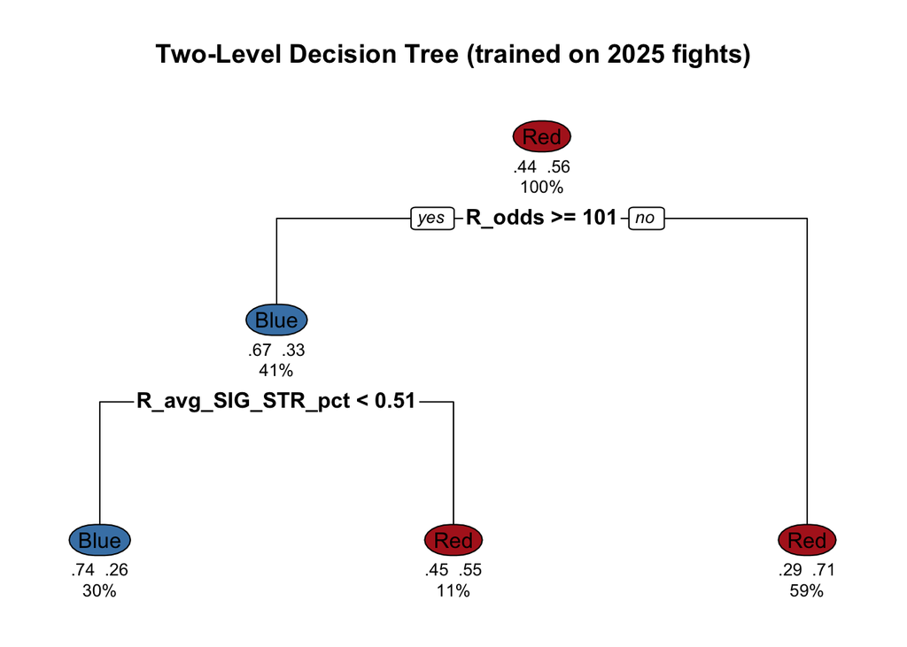

```r
if (requireNamespace("rpart.plot", quietly = TRUE)) {
  rpart.plot::rpart.plot(tree_ufc, type = 2, extra = 104, under = TRUE,
                         box.palette = c("steelblue", "firebrick"),
                         main = "Two-Level Decision Tree (trained on 2025 fights)")
} else {
  plot(tree2, margin = 0.1); text(tree_ufc, use.n = TRUE, cex = 0.8)
}
```

```r
# In-sample (2025) accuracy, for reference only
mean(predict(tree_ufc, train25, type = "class") == train25$Winner)
```

```
## [1] 0.7017544
```

```r
# Predict every 2026 fight
fights26$P_Red          <- predict(tree_ufc, fights26, type = "prob")[, "Red"]
fights26$Pred_Winner    <- as.character(predict(tree_ufc, fights26, type = "class"))
fights26$Pred_Fighter   <- ifelse(fights26$Pred_Winner == "Red",
                                  as.character(fights26$R_fighter),
                                  as.character(fights26$B_fighter))
fights26$Favorite       <- ifelse(fights26$R_odds < fights26$B_odds, "Red", "Blue")

pred_table <- fights26[order(fights26$date),
                       c("date", "R_fighter", "B_fighter", "R_odds", "B_odds",
                         "Pred_Winner", "Pred_Fighter", "P_Red", "Winner")]
pred_table$P_Red <- round(pred_table$P_Red, 3)
names(pred_table)[names(pred_table) == "Winner"] <- "Actual_Winner"
pred_table
```

```
##           date                R_fighter                B_fighter R_odds B_odds
## 106 2026-01-24           Justin Gaethje           Paddy Pimblett    200   -245
## 107 2026-01-24            Sean O'Malley              Song Yadong   -225    188
## 108 2026-01-24      Waldo Cortes Acosta            Derrick Lewis   -335    270
## 109 2026-01-24            Natalia Silva           Rose Namajunas   -330    265
## 110 2026-01-24             Arnold Allen               Jean Silva    184   -220
## 111 2026-01-24        Umar Nurmagomedov      Deiveson Figueiredo  -1500    870
## 112 2026-01-24            Ateba Gautier           Andrey Pulyaev  -1000    660
## 113 2026-01-24            Nikita Krylov       Modestas Bukauskas    112   -132
## 114 2026-01-24               Alex Perez          Charles Johnson    154   -184
## 115 2026-01-24               Josh Hokit           Denzel Freeman   -260    215
## 116 2026-01-24              Adam Fugitt                Ty Miller    330   -420
## 93  2026-01-31    Alexander Volkanovski              Diego Lopes   -162    136
## 94  2026-01-31               Dan Hooker       Benoit Saint Denis    310   -400
## 95  2026-01-31            Rafael Fiziev           Mauricio Ruffy   -124    106
```

[output cut: 219 more lines]

```r
write.csv(pred_table, "ufc_2026_tree_predictions.csv", row.names = FALSE)
```

```r
# Score the 2026 fights that already have a result
done26 <- fights26[!is.na(fights26$Winner), ]
done26$Winner      <- factor(done26$Winner, levels = c("Blue", "Red"))
done26$Pred_Winner <- factor(done26$Pred_Winner, levels = c("Blue", "Red"))

if (nrow(done26) > 0) {
  print(confusionMatrix(done26$Pred_Winner, done26$Winner, positive = "Red"))

  # AUC needs both outcomes present and more than one distinct predicted probability
  # (a 2-level tree has at most 4 distinct probabilities, so AUC will be coarse)
  if (length(unique(done26$Winner)) == 2 && length(unique(done26$P_Red)) > 1) {
    print(auc(roc(done26$Winner, done26$P_Red, levels = c("Blue", "Red"))))
  }

  # Compare with the two baselines, using the 2025 majority corner
  maj25 <- names(which.max(table(train25$Winner)))
  data.frame(
    model    = c("Decision tree (depth 2)", paste0("Always ", maj25, " (2025 majority)"),
                 "Always the betting favorite"),
    accuracy = c(mean(done26$Pred_Winner == done26$Winner),
                 mean(done26$Winner == maj25),
                 mean(done26$Favorite == done26$Winner, na.rm = TRUE))
  )
} else {
  cat("None of the 2026 fights in the file have a result yet - predictions only.\n")
}
```

```
## Confusion Matrix and Statistics
##
##           Reference
## Prediction Blue Red
##       Blue   25   8
##       Red    26  56
##
##                Accuracy : 0.7043
##                  95% CI : (0.6121, 0.7858)
##     No Information Rate : 0.5565
##     P-Value [Acc > NIR] : 0.0008168
##
##                   Kappa : 0.3788
##
##  Mcnemar's Test P-Value : 0.0035515
##
##             Sensitivity : 0.8750
##             Specificity : 0.4902
##          Pos Pred Value : 0.6829
##          Neg Pred Value : 0.7576
##              Prevalence : 0.5565
##          Detection Rate : 0.4870
##    Detection Prevalence : 0.7130
##       Balanced Accuracy : 0.6826
##
##        'Positive' Class : Red
##
```

```
## Area under the curve: 0.7439
```

```
##                         model  accuracy
## 1     Decision tree (depth 2) 0.7043478
## 2  Always Red (2025 majority) 0.5565217
## 3 Always the betting favorite 0.7478261
```

**Interpretation (fill in after knitting):** For our Decision Tree, we decided to go with a two-level decision tree, trained only on 2025 fights, shows that pre-fight information can predict UFC winners, and that the betting market carries most of that signal. We wanted the decision tree to predict winners based on 2025 data for 2026 fights. The tree’s first and most important split was the Red fighter’s betting odds. When Red was the favorite or an even pick (59% of 2025 fights), Red won 71% of the time. When Red was the underdog (41% of fights), Blue won 67% of the time. The only other variable the tree used was the Red fighter’s career significant-strike accuracy, and only for Red underdogs. Underdogs landing less than 51% of their significant strikes lost 74% of the time. Underdogs landing 51% or more won 55% of the time, which is close to a coin flip, so the tree’s confidence in that group is low.

This analysis has a few limitations. The model learned from only one year of fights, and the 2026 test covers just two months. The tree has only two levels, and its only non-odds rule covered a small share of fights. A few odds entries also look wrong (for example, both fighters listed as favorites), so cleaning the odds data would help. Next steps are to train on several seasons, use features that measure the gap between the two fighters (Red minus Blue) instead of Red’s stats alone, try deeper trees tuned with cross-validation, and compare against the logistic regression in Section 5. Together these would show whether fighter statistics can consistently beat the betting market, which is the core of the business question.